```python
import bs4 as bs
import datetime as dt
import matplotlib.pyplot as plt
from matplotlib import style
import matplotlib.dates as mdates
from mpl_finance import candlestick_ohlc
import numpy as np
import os
import pandas as pd
import pandas_datareader.data as web
import pickle
import requests
style.use('ggplot')
```

### In order to pull stock data of the S&P 500 of Yahoo Fiance, I need a list of tickers. The following function will pull the list of ticker from Wikipedia and save it in a pickle file.

```python
def save_sp500_tickers():
    resp = requests.get('https://en.wikipedia.org/wiki/List_of_S%26P_500_companies')
    soup = bs.BeautifulSoup(resp.text,'lxml')
    table = soup.find('table',{'class':'wikitable sortable'})
    tickers = []
    for row in table.findAll('tr')[1:]:
        ticker = row.findAll('td')[0].text.strip()
        tickers.append(ticker)

    with open('sp500tickers.pickle','wb') as f:
        pickle.dump(tickers,f,pickle.HIGHEST_PROTOCOL)

    return tickers
```

### Next step is to use the list of tickers created above to get the stock data from Yahoo Fiance. The following function will get the data for each ticker and save them in a CSV file format.

```python
def get_data_from_yahoo(reload_sp500=False):
    if reload_sp500:
        tickers = save_sp500_tickers()
    else:
        with open('sp500tickers.pickle','rb') as f:
            tickers = pickle.load(f)

    if not os.path.exists('stock_dfs'):
        os.makedirs('stock_dfs')

    start = dt.datetime(2000,1,1)
    end = dt.datetime(2019,12,31)

    for ticker in tickers:
        print(ticker)
        if not os.path.exists('stock_dfs/{}.csv'.format(ticker)):
            try:
                df = web.DataReader(ticker,'yahoo', start,end)
                df.to_csv('stock_dfs/{}.csv'.format(ticker))
            except Exception as ex:
                print('Error:',ex)
        else:
            print('Already have {}'.format(ticker))
```

### Now that we have the data of the S&P 500 stocks but they are saved in seperate files. To do an correlation analysis, first I would need to complile them all into one big data file. In this example I will only use the Adjusted Close data of all the stock to do analysis.

```python
def compile_data():
    with open ('sp500tickers.pickle','rb') as f:
        tickers = pickle.load(f)

    main_df = pd.DataFrame()

    for count,ticker in enumerate(tickers):
        try:
            df = pd.read_csv('stock_dfs/{}.csv'.format(ticker))
            df['Date'] = pd.to_datetime(df['Date'])
            df.set_index('Date', inplace=True)

            df.rename(columns = {'Adj Close': ticker}, inplace=True)
            df.drop(['Open','High','Low','Close','Volume'],1,inplace = True)
        except Exception as ex:
            print('Error:',ex)
        if main_df.empty:
            main_df = df
        else:
            try:
                main_df = main_df.join(df,how='outer')
            except Exception as ex:
                print('Error:',ex)
        if count% 10 == 0:
            print(count)
    print(main_df.head)
    main_df.to_csv('sp500_joined_closes.csv')
```

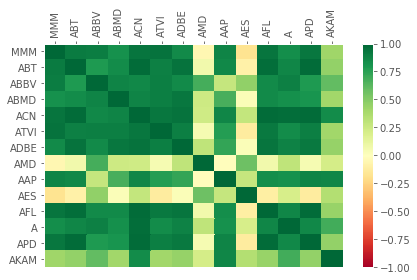

```python
def visualize_data():

    df = pd.read_csv('sp500_joined_closes.csv', usecols = list(range(1,15)))
    #df['AAPL'].plot()
    #plt.show()
    df_corr = df.corr()

    data = df_corr.values
    fig = plt.figure()
    ax = fig.add_subplot(1,1,1)
    ax.set_xticks(np.arange(data.shape[0]) +0.5, minor=False)
    ax.set_yticks(np.arange(data.shape[1]) +0.5, minor=False)

    heatmap = ax.pcolor(data,cmap=plt.cm.RdYlGn)
    fig.colorbar(heatmap)
    ax.invert_yaxis()
    ax.xaxis.tick_top()

    column_labels = df_corr.columns
    row_labels = df_corr.index

    ax.set_xticklabels(column_labels)
    ax.set_yticklabels(row_labels)
    plt.xticks(rotation=90)
    heatmap.set_clim(-1,1)
    plt.tight_layout()
    plt.show()
visualize_data()
```

### Since we already have the stock data for each of the SP 500 company. I decided that it would be beneficial to have a way to represent the individual stock data. The following function will take in a company's ticker name and a time frame to produce a candlestick chart and volumn plot for such company.

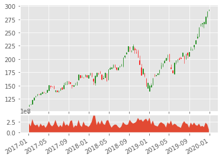

```python
def candle_stick(ticker,start = None, end = None):
    df = pd.read_csv('stock_dfs/{}.csv'.format(ticker),parse_dates = True, index_col = 0)
    if start == None and end == None:
        df_ohlc = df['Adj Close'].resample('10D').ohlc()
        df_volume = df['Volume'].resample('10D').sum()
        df_ohlc.reset_index(inplace=True)


    elif start != None and end == None:
        index = pd.date_range(start= start, end=dt.datetime.today().strftime('%Y%m%d'), name='Date')
        df_re = pd.DataFrame(data=index,index = index)
        df = df_re.join(df,how = 'inner')
        df["Date"] = pd.to_datetime(df["Date"], unit='s')
        df_ohlc = df['Adj Close'].resample('10D').ohlc()
        df_volume = df['Volume'].resample('10D').sum()
        df_ohlc.reset_index(inplace=True)

    else:
        index = pd.date_range(start= start, end=end, name='Date')
        df_re = pd.DataFrame(data=index,index = index)
        df = df_re.join(df,how = 'inner')
        df["Date"] = pd.to_datetime(df["Date"], unit='s')
        df_ohlc = df['Adj Close'].resample('10D').ohlc()
        df_volume = df['Volume'].resample('10D').sum()
        df_ohlc.reset_index(inplace=True)


    df_ohlc['Date'] = mdates.date2num(df_ohlc['Date'])

    ax1 = plt.subplot2grid((6,1),(0,0), rowspan=5, colspan=1)
    ax2 = plt.subplot2grid((6,1),(5,0), rowspan=1, colspan=1, sharex=ax1)
    ax1.xaxis_date()

    candlestick_ohlc(ax1, df_ohlc.values, width = 2, colorup ='g')
    ax2.fill_between(df_volume.index.map(mdates.date2num), df_volume.values, 0)
    plt.setp(ax2.get_xticklabels(), rotation=30, horizontalalignment='right')
    plt.setp(ax1.get_xticklabels(), visible=False)
    plt.show()
candle_stick('AAPL',start = '1/1/2017')
```